# Homework 3: Is Donald Trump going to win the republican nomination?

**This homework is due Tuesday March 8, 2016 at 8PM EST. When complete, submit your code in an R Markdown file and the knitted HTML via GitHub.**

# Motivation

In 2012 Nate Silver, and other data scientists, [predicted the outcome of each state correctly](http://mashable.com/2012/11/07/nate-silver-wins/#2WkAUaXCVaqw). They did this by aggregating data from many polls to create more precise estimates than what one single poll can provide.

In this homework, we will try to predict the results of the democratic and republican primaries by studying the performance of polls in elections that already occurred and then aggregating results.

# Problem 1

The first step in our analysis will be to wrangle the data in a way that will simplify the analysis. Ultimately, we want a table of results with each poll represented by a row and including results for each candidate as well as information about the poll such as name and date.

# Problem 1A

Install and load the `pollstR` package. This package provides functions to access data in the Huffington Post’s database. Read the help file for the `pollstr_polls()` function and write a function that reads **all** the polls related to the republican primaries. Name the object `race2016`. Hint: Visit [this webpage](http://elections.huffingtonpost.com/pollster/api) to select the right `topic` and make sure to change the `max_pages` argument.

# Problem 1B

Examine and familiarize yourself with the `race2016` object. Note that the `questions` component has a table with election results. Look at the `topic` component of the `questions` component. Create a new table with only the results from the `2016-president-gop-primary` and only state (or territory) polls, no national polls. Hint: create a new object called `results` with the table of results and use `dplyr`. How many rows are we left with?

```r
library(dplyr)
results <- tbl_df(race2016$questions %>% filter(topic=="2016-president-gop-primary" & state != "US"))
results %>% nrow()
```

```
## [1] 4788
```

## Problem 1C

In Problem 1B, we created a table called `results` with over 4000 rows. Does this mean that we have data for 4000 polls? How many polls did we actually have? Hint: look at the `id` column and use the `group_by` command.

```r
table(results$id) %>% nrow()
```

```
## [1] 391
```

## Problem 1D

Look at the first row of your `results` table. What date was this poll conducted? Hint: Use the `polls` component of the `race2016` object to find the date.

```r
id1 <- results[1,]$id
race2016$polls %>% filter(id == id1) %>% select(start_date, end_date)
```

```
##   start_date   end_date
## 1 2016-03-04 2016-03-05
```

## Problem 1E

Now examine the candidates in the “choices” column included in `results` table. Hint: use the `table()` function. Note that there are several choices that not going to be informative. For example, we have candidates that have dropped out. We also have entries such as `No one`, `No One` and `No Preference`. Filter the `results` table to include only Rubio and Trump.

```r
library(tidyr)
results <- filter(results, choice %in% c("Rubio","Trump"))
results %>% nrow()
```

```
## [1] 728
```

## Problem 1F

In our `results` table, we have one row for each candidate in each poll. Transform the `results` table to have one row for each poll and columns for each Rubio and Trump. Next, create a column called `diff` with the difference between Trump and Rubio. Hint: Remove the `first_name` and `last_name` columns then use the `tidyr` function `spread()`.

```r
#remove duplicated polls
results <- unique(results)
results <- results %>% select(-c(first_name,last_name)) %>% spread(key=choice, value=value) %>% mutate(Trump=Trump/100, Rubio=Rubio/100, diff=Trump-Rubio) %>% filter(!is.na(diff))
results %>% nrow()
```

```
## [1] 338
```

## Problem 1G

For each poll in the `results` table, we want to know the start date and the end date of the poll along with the pollster name and the type of poll it was. Hint: This information is in the `polls` component of `race2016`. You can select the relevant columns then use the `id` column to join the tables. One of the `join` functions in `tidyr` will do the trick.

```r
polls <- race2016$polls %>%  select(id, pollster, start_date, end_date, method)
#remove duplicates
polls <- unique(polls)
results <- inner_join(results, polls, by = "id")
results %>% nrow()
```

```
## [1] 338
```

## Problem 1H

Study the type of values in the `pollster` column. Notice that you have many different values but that certain names commonly appear in these values. For example, consider the name “NBC” in the `pollster` column. NBC here is the Survey House. Use a join function again to add the survey house to the `results` table. Rename the column `house`. Hint: `race2016$survey_house` has the information you need.

```r
house <- race2016$survey_houses %>%  select(id, name) %>% rename(house = name)
#remove duplicates
house <- unique(house)
results <- inner_join(results, house, by = "id")
results %>% nrow()
```

```
## [1] 356
```

We now have a table with all the information we need. We will now use the results from Iowa, New Hampshire, Nevada and South Carolina to determine how to create a prediction for upcoming primaries.

## Problem 2A

Use an internet search to determine the results for the Iowa, New Hampshire, Nevada and South Carolina primaries for the top two candidates. Create a table called `actual` with this information. Also, create a column with the actual election difference. Use a join function to add this information to our `results` table.

```r
actual <- data.frame(c("IA", "NH", "NV", "SC"), c(24.3, 35.3, 45.9, 32.5), c(23.1, 10.6, 23.9, 22.5), stringsAsFactors = FALSE)
names(actual) <- c("state", "act_Trump", "act_Rubio")
actual <- mutate(actual, act_Trump = act_Trump/100, act_Rubio = act_Rubio/100, act_diff=act_Trump-act_Rubio)
result_actual <- inner_join(results, actual, by="state")
```

## Problem 2B

Create boxplots of the poll results for Trump in Iowa stratified by the pollster survey house for polls having more than 4 total results. Add a horizontal line with the actual results. Hint: Use the `group_by`, `mutate`, `filter` and `ungroup` functions in `dplyr` for the filtering step.

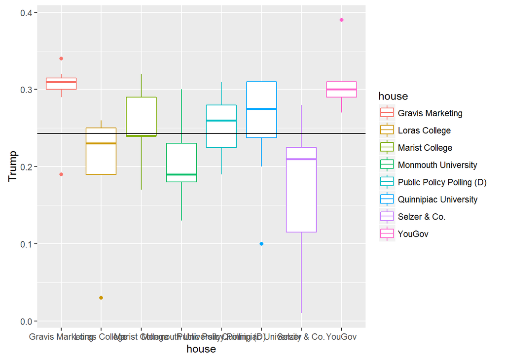

```r
library(ggplot2)
IA_result <- result_actual %>% filter(state=="IA") %>% group_by(house) %>% mutate(num_polls = n()) %>% filter(num_polls > 4) %>% ungroup
IA_result %>% ggplot(aes(house, Trump, col=house)) + geom_boxplot() + geom_hline(aes(yintercept=act_Trump))
```

## Problem 2C

Using the poll results for Trump in Iowa, compute the standard deviation for the results from each pollster house for polls having more than 4 total results. Then, study the typical standard deviation sizes used in these polls. Create a new table with two columns: the observed standard deviation and the standard deviations that theory predicts. For the prediction you have several observations. Pick the smallest one. Which is larger, the observed or the theoretical?

```r
obs_SD <- IA_result %>% group_by(house) %>% summarize(obs_SD = sd(Trump))
theory_SD <- IA_result %>% group_by(house) %>% summarize(N=min(observations)) %>% mutate(theory_SD=sqrt(0.5*0.5/N)) %>% select(-N)
inner_join(obs_SD, theory_SD, by="house")
```

```
## Source: local data frame [8 x 3]
##
##                       house     obs_SD  theory_SD
##                       (chr)      (dbl)      (dbl)
## 1          Gravis Marketing 0.04894117 0.03004209
## 2             Loras College 0.09444575 0.02238307
## 3            Marist College 0.05718391 0.02703690
## 4       Monmouth University 0.06348228 0.02500000
## 5 Public Policy Polling (D) 0.04457204 0.02263394
## 6     Quinnipiac University 0.07269064 0.02086960
## 7              Selzer & Co. 0.10221360 0.02500000
## 8                    YouGov 0.04604346 0.02254174
```

The observed standard deviation is larger.

## Problem 2D

Now using the data from Problem 2C, plot the individual values against the time the poll was taken (use the `end_date`). Repeat this for each of the four states. Use color to denote pollster house. Using this plot, explain why the theory does not match the observed results?

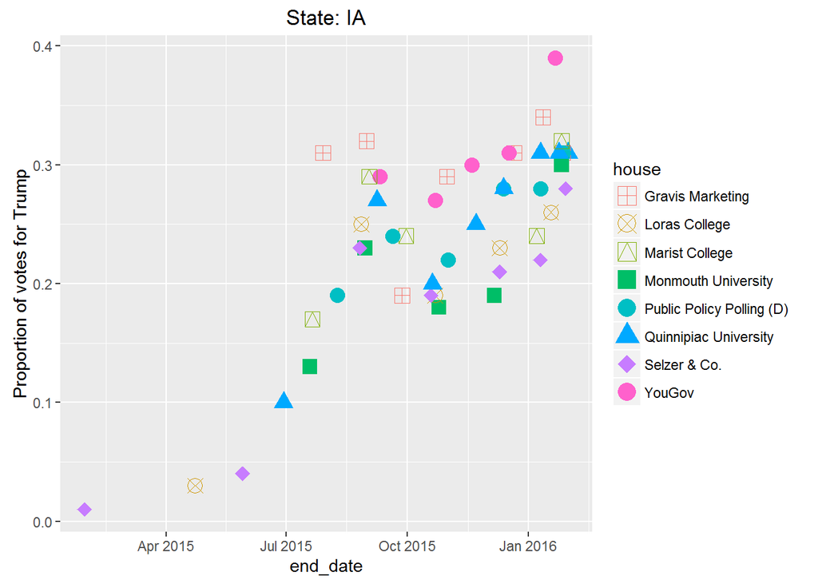

```r
plot_Poll <- function(s){
    result_actual %>% filter(state==s) %>% group_by(house) %>% filter(n()>4) %>% ggplot(aes(x=end_date, y=Trump, group=house)) + geom_point(aes(color=house, shape=house), size=4) +  scale_shape_manual(values=c(12:21)) + guides(colour = guide_legend(override.aes = list(size=5))) +
 ylab("Proportion of votes for Trump") + labs(title=paste("State:", s))

}
plot_Poll(s="IA")
```

[figure not shown]

```r
plot_Poll(s="NV")
```

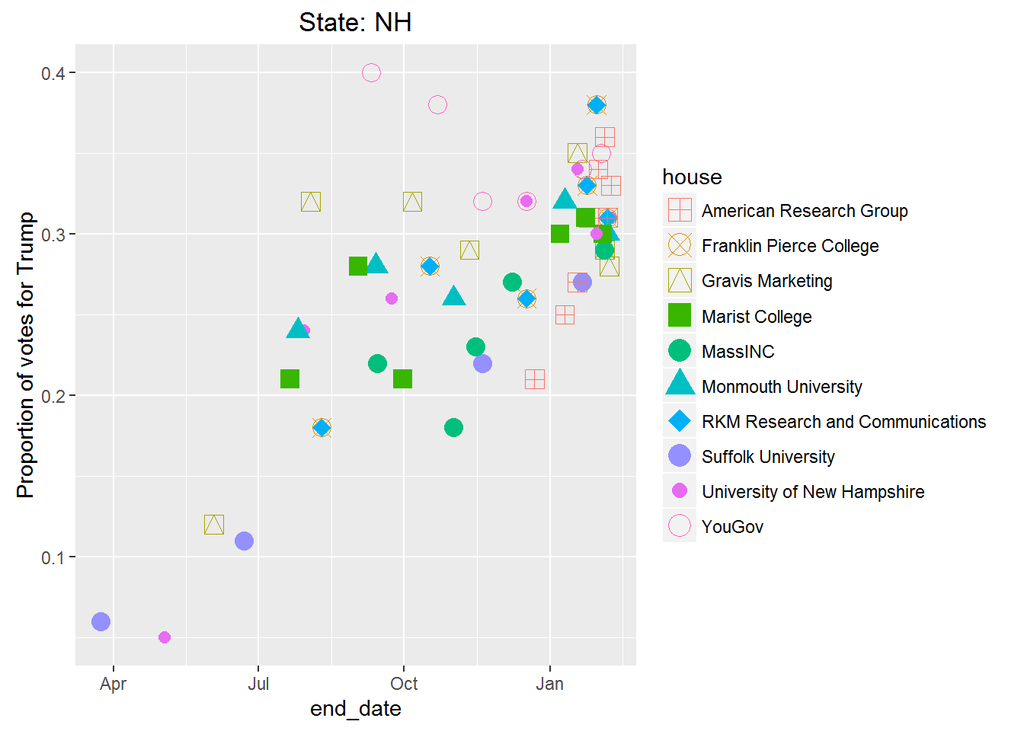

```r
plot_Poll(s="NH")
```

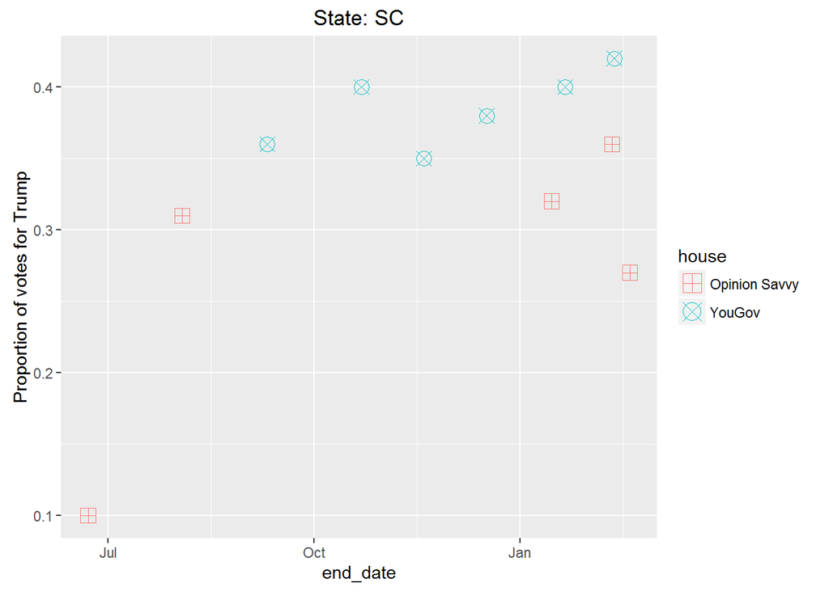

```r
plot_Poll(s="SC")
```

The theory doesn’t match the observed results because the proportion voting for Trump changed over time. Hence there is variability in the observed results compared to be a assumption of a fixed proportion in the theory. Some of the polls were taken more than 6 months before the election and the opinion of people have changed over time, i.e. there is a time effect which we need to model.

## Problem 2E

Consider the Trump - Rubio difference. For each poll in IA, NH, SC and NV, compute the error between the prediction and actual election results. Use exploratory data analysis to get an idea of how time and pollster impacts accuracy.

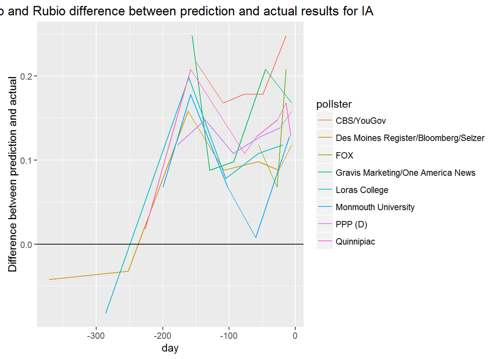

```r
library(lubridate)
result_actual <-  mutate(result_actual, diff_pred = diff-act_diff)

# Calulate number of days between the poll and the results
results_date <- data.frame(c("IA", "NH", "NV", "SC"), c(ymd("2016-02-01"),ymd("2016-02-09"),ymd("2016-02-23"),ymd("2016-02-20")), stringsAsFactors = FALSE)
names(results_date) <- c("state", "results_date")
result_actual <- inner_join(result_actual, results_date, by="state") %>% mutate(day=as.numeric(ymd(start_date) - results_date))

plot_Diff <- function(s){
  result_actual %>% filter(state==s) %>% group_by(pollster) %>% filter(n()>4) %>%     ggplot(aes(x=day, y=diff_pred)) + geom_line(aes(color=pollster)) +                 ylab("Difference between prediction and actual") + geom_hline(aes(yintercept=0)) +  labs(title=paste("Trump and Rubio difference between prediction and actual results for", s))
}

plot_Diff(s="IA")
```

[figure not shown]

```r
plot_Diff(s="NV")
```

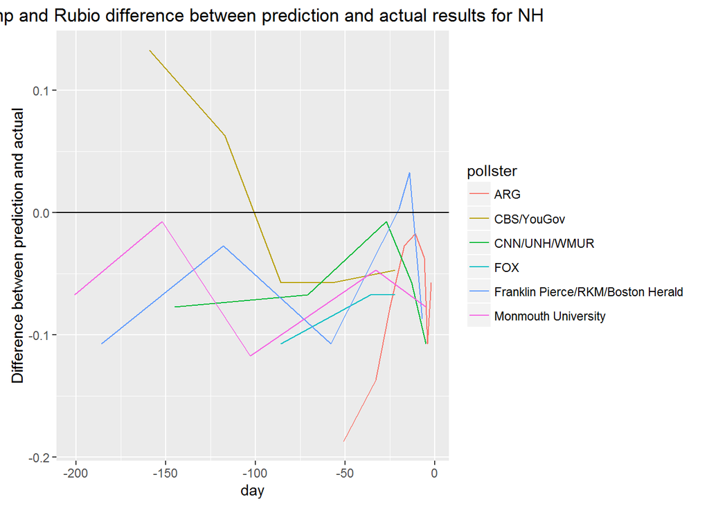

```r
plot_Diff(s="NH")
```

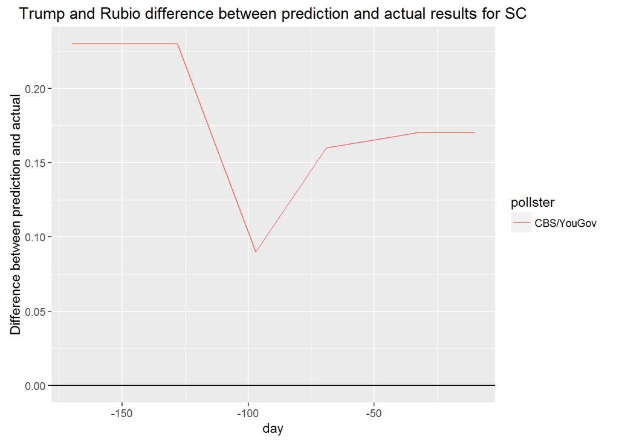

```r
plot_Diff(s="SC")
```

# Problem 2F

For polls from IA, NH, and SC, aggregate all polls from within 1 week of the election (use the `start_date` to determine cutoff) to provide a 95% confidence interval for the difference between Trump and Rubio. Compare the following two approaches: (1) the method that assumes that all variance comes from sampling error and (2) the approach that estimates variance empirically.

```r
for(s in c("IA","NH","SC")){
t <- result_actual %>% filter(state==s & day >= -7) %>%  summarize(n=n(), avg=mean(diff), sd=sd(diff), avgObs = mean(observations))
#1. Using t-distribution to small number of polls
cat("95% CI for", s, "(", t$avg + c(-1,1)*qt(0.975, df=t$n-1)*t$sd/sqrt(t$n),")  using t-distribution", "\n")

#2. Estimate variance empiritically
cat("95% CI for", s, "(", t$avg + c(-1,1)*qt(0.975, df=t$n-1) * 2 * sqrt(t$avg*(1-t$avg)/t$avgObs)/sqrt(t$n), ") using theory of polls", "\n")
}
```

```
## 95% CI for IA ( 0.04164323 0.1850234 )  using t-distribution
## 95% CI for IA ( 0.0881287 0.138538 ) using theory of polls
## 95% CI for NH ( 0.1396463 0.1790203 )  using t-distribution
## 95% CI for NH ( 0.1415403 0.1771264 ) using theory of polls
## 95% CI for SC ( 0.1221388 0.1747843 )  using t-distribution
## 95% CI for SC ( 0.1309036 0.1660195 ) using theory of polls
```

# Problem 3

Before seeing any polls my *prior belief* is that Rubio will beat Trump in Florida. If I were to quantify this belief I would say that the distribution of the `Trump` - `Rubio` was normal with mean $\mu=-20$ percent and standard deviation $\tau=10$. Let’s call the difference $\theta$. Then

$\theta \sim N( \mu, \tau)$

# Problem 3A

Under my prior belief, what is the chance that Trump would beat Rubio in Florida.

```r
cat("Probability of Trump beating Rubio in Florida =", 1- pnorm(20/10))
```

```
## Probability of Trump beating Rubio in Florida = 0.02275013
```

# Problem 3B

```r
poll_FL <- results %>% filter(state=="FL") %>% summarize(n=n(), theta=mean(diff), sigma=sd(diff))
poll_FL
```

```
## Source: local data frame [1 x 3]
##
##       n     theta     sigma
##   (int)     (dbl)     (dbl)
## 1    23 0.1430435 0.1057628
```

$\hat{\theta} \sim N( \theta, \sigma/ \sqrt{25})$

Now use the Central Limit Theorem to construct a confidence interval.

```r
poll_FL$theta + c(-1,1)*qnorm(0.975)*poll_FL$sigma/sqrt(poll_FL$n)
```

```
## [1] 0.09982026 0.18626670
```

## Problem 3C

Combine these two results to provide the mean and standard deviation of a posterior distribution for $\theta$.

```r
mu <- -20
tau <- 10
theta <- poll_FL$theta
sigma <- poll_FL$sigma
mean_pos <- mu + (1 - (sigma^2/(sigma^2 + tau^2)))*(theta - mu)
var_pos <- 1/(1/tau^2 + 1/sigma^2)
cat("The posterior distribution has mean", mean_pos, "and standard deviation", sqrt(var_pos))
```

```
## The posterior distribution has mean 0.1407906 and standard deviation 0.1057569
```

## Problem 3D

Use the result form Problem 3C to provide your estimate of Trump beating Rubio in Florida.

```r
cat("Probability of Trump beating Rubio in Florida  =" ,1-pnorm(mean_pos/sqrt(var_pos)))
```

[output not shown]

# Problem 4

Use the poll data as well as the results from Super Tuesday (March 1st) and other election results that happen before the deadline to make predictions for each remaining primary. Then use these results to estimate the probability of Trump winning the republican nomination. Justify your answer with figures, statistical arguments, and Monte Carlo simulations.

It will help to learn about how delegates are assigned. Here is [the manual].(http://www.scribd.com/doc/294928557/2016-Presidential-Nominating-Process-Book-version-2-0-Dec-2015-pdf)